# VU [183.653](https://tiss.tuwien.ac.at/course/courseDetails.xhtml?courseNr=183653) Methodical, industrial Software-Engineering using the Haskell **fun**ctional programming language

2013-04-22

# Last Time

- GHC's Memory Management
- Value representation on the heap
  - `String` vs. `ByteString`/`Text`
  - `[a]` vs. `Vector`

# Addendum to last lecture

- Size requirements of common data structures  
  (ignoring shared instances; sizes in **W**ords and **B**ytes):

  | Type | Size (to be rounded up to full **W**s) |
  | --- | --- |
  | `(ta,tb)` | 3 **W** + size(`ta`) + size(`tb`) |
  | `[t]` | 3*N* **W** + *N* size(`t`) |
  | `ByteString` *(strict)* | 9 **W** + *N* **B** |
  | `Text` *(strict)* | 6 **W** + 2*N<sup>+</sup>* **B** |
  | `Map tk tv` | 6*N* **W** + *N* (size(`tk`) + size(`tv`)) |
  | `Set t` | 5*N* **W** + *N* size(`t`) |
  | `IntMap t` | (3*N* + 5(*N*-1)) **W** + *N* size(`t`) |
  | `IntSet` | (2*N* + 5(*N*-1)) **W** |
  | `HashMap tk tv` | 4.5*N* **W** + *N* (size(`tk`) + size(`tv`)) |
  | `HashSet t` | 4.5*N* **W** + *N* size(`t`) |
  | `Vector t` *(boxed)* | (6 + *N*) **W** + *N* size(`t`) |

# Today

- GHC Compiler Stages
- GHC Core
- Heap Profiling
- Memory Leaks

# GHC Pipeline

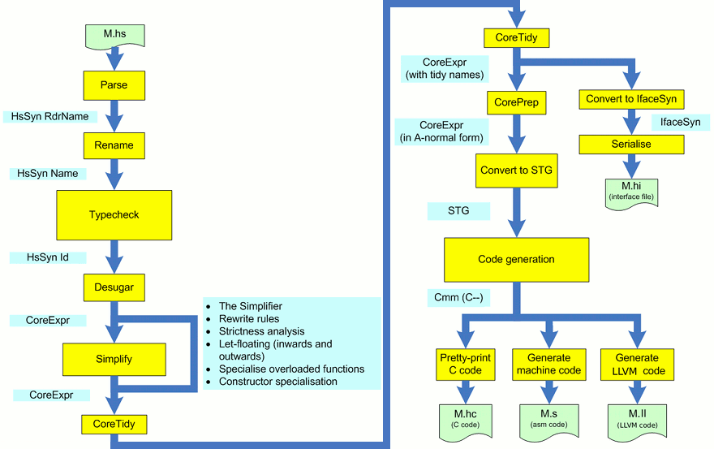

[*(source: GHC Commentary)*](http://hackage.haskell.org/trac/ghc/wiki/Commentary/Compiler/HscMain)

# GHC Pipeline *(cont.)*

- Source language is **parsed**, **name-resolved** and **type-inferred/checked** into `HsSyn {RdrName,Name,Id}`.
- Only then is `HsSyn Id` **desugared** into the *much* simpler typed `CoreExpr` representation (i.e. **GHC Core**).
- Most of GHC's **optimizations** are implemented in terms of core-to-core transformations.
- Finally, `CoreExpr` is transformed into STG represention for **code generation** and after that fed as "C--" into the selected code-generator backend.
- GHC can **output the intermediate data structures** after each stage via `-ddump-…` flags.

# GHC Core

- Similiar to *Haskell kernel* sub-language shown in the 1<sup>st</sup> lecture
- Formal foundation: ["System F with Type Equality Coercions"](http://research.microsoft.com/en-us/um/people/simonpj/papers/ext-f/tldi22-sulzmann-with-appendix.pdf)
- GHC's representation of `CoreExpr`:

  ```haskell
  type CoreExpr = Expr Var

  data Expr b = Var   Id
              | Lit   Literal
              | App   (Expr b) (Arg b)
              | Lam   b (Expr b)
              | Let   (Bind b) (Expr b)
              | Case  (Expr b) b Type [Alt b]
              | Cast  (Expr b) Coercion
              | Tick  (Tickish Id) (Expr b)
              | Type  Type
              | Coercion Coercion
              deriving (Data, Typeable)
  ```

# GHC Core *(cont.)*

- For debugging purposes, there's a more convenient  
  ["External Representation for the GHC Core Language"](http://www.haskell.org/ghc/docs/7.6.2/html/users_guide/an-external-representation-for-the-ghc-core-language-for-ghc-6.10.html)  
  documented in the *GHC User's Guide*.
- Core (after all `simpl`ifier passes) can be easily extracted via

  ```
  ghc -fforce-recomp -ddump-simpl -dsuppress-uniques \
      -dsuppress-coercions -dsuppress-type-applications \
      -O2 -c Foo.hs
  ```

  (alternatively, `-dsuppress-all` removes most annotations)
- Sometimes more convenient & with syntax coloring: the `ghc-core` tool (install with `cabal install ghc-core`):

  ```
  ghc-core --no-asm -- Foo.hs
  ```

# GHC Core *(cont.)*

# Understanding GHC Core

- The following simple Haskell example

  ```haskell
  {-# LANGUAGE BangPatterns #-}
  mkPair  a  = (a,a)
  mkPair' !a = (a,a)  -- same as: mkPair' a = seq a (a,a)
  ```

  gets compiled to Core (`-ddump-simpl -dsuppress-all`):

  ```haskell
  mkPair  = \ @ t_aeT a_aeH -> (a_aeH, a_aeH)
  mkPair' = \ @ t_aeM a_aeI ->
            case a_aeI of a1_XeL { __DEFAULT -> (a1_XeL, a1_XeL) }
  ```

- Core is explicitly typed: `@t_aeT` and `@t_aeM` denote type-arguments.
- Core's `case`-expression has an additional binder `a1_XeL`.
- Even though the `case`-expression is pattern matched against the wildcard pattern `__DEFAULT` the `a_aeI` value is forced to WHNF!

# Understanding GHC Core *(cont.)*

- The `case` expression in Core

  ```haskell
  case a of a1 { __DEFAULT -> (a1,a1); pat1 -> exp1; pat2 -> exp2 }
  ```

  can be thought of in terms of H98 as

  ```haskell
  case a of
    a1 | seq a1 False -> undefined
    a1@pat1 -> exp1
    a1@pat2 -> exp2
    a1@_    -> (a1,a1)
  ```

- `__DEFAULT` comes first but is matched last.
- Pattern failures are explicit in Core (and are attached to `__DEFAULT`).

# Understanding GHC Core *(cont.)*

- Let's try again with non-polymorphic version:

  ```haskell
  {-# LANGUAGE BangPatterns #-}
  mkPair, mkPair' :: Int -> (Int,Int)
  mkPair  a  = (a,a)
  mkPair' !a = (a,a)
  ```

- Core now reads:

  ```haskell
  mkPair  = \ a_aeI -> (a_aeI, a_aeI)
  mkPair' = \ a_aeJ ->
            case a_aeJ of a1_XeM { I# ipv_seR -> (a1_XeM, a1_XeM) }
  ```

- The `@`-arguments have vanished.
- Wildcard pattern `__DEFAULT` has been replaced by `I# _` pattern.

# Typeclasses in Core

- The simple class & instance definition:

  ```haskell
  class Monoid a where
    (<>) :: a -> a -> a
    ie   :: a

  instance Monoid () where
    () <> () = ()
    ie       = ()
  ```

- ...results in the following Core definitions:

  ```haskell
  -- created by class definition:
  <> = \ @a (d :: Monoid a) -> case d of _ { D:Monoid m1 _ -> m1 }
  ei = \ @a (d :: Monoid a) -> case d of _ { D:Monoid _ m2 -> m2 }

  -- created by instance definition:
  $fMonoid()_$c<> = \ (v1 :: ()) (v2 :: ()) ->
                    case v1 of _ { () -> v2 }

  $fMonoid() = D:Monoid @() $fMonoid()_$c<> ()
  ```

# Data types in Core

- Data constructors are not defined explicitly in Core unless strict fields occur  
  (in which case a constructor-wrapper is defined):

  ```haskell
  data Foo a = Foo a
  data Bar a = Bar !a
  data Doo = Doo { unDoo :: Int }

  mkFoo = Foo
  mkBar = Bar
  ```

  results in

  ```haskell
  $WBar :: forall a. a -> Bar a
  $WBar = \ @a (v :: a) -> case v of v2 { __DEFAULT -> Bar @a v2 }

  unDoo = \ (d :: Doo) -> case d of _ { Doo d -> d }

  mkBar = $WBar
  mkFoo = Foo
  ```

# Newtypes in Core

- Newtypes result in coercions in Core:

  ```haskell
  newtype Foo = Foo Int

  incFoo (Foo i) = Foo (i+1)
  ```

  results in

  ```haskell
  incFoo :: Foo -> Foo
  incFoo = a `cast` (<Foo> -> Sym <(NTCo:Foo)>
                     :: (Foo -> Int) ~# (Foo -> Foo))

  a :: Foo -> Int
  a = \ ds -> + @ Int $fNumInt (ds `cast`
                                (<NTCo:Foo> :: Foo ~# Int)) (I# 1)
  ```

- Use `-dsuppress-coercions` to reduce clutter by `cast`-terms

# Sum in Core (`-O0`)

- Now let's try with a more complex function:

  ```haskell
  sum :: [Int] -> Int
  sum (x:xs) = x + sum xs
  sum []     = 0
  ```

  compiled to Core w/ `-O0` (and keeping type-annotations):

  ```haskell
  sum = \ (ds :: [Int]) ->
        case ds of _ {
          []       -> I# 0;
          :  x xs  -> + @Int $fNumInt x (sum xs)
        }
  ```

- Core doesn't support infix operators: `:` and `+` are in prefix position.
- `$fNumInt` is the `Num` typeclass dictionary for `Int` and `+` is field-accessor.

# Sum in Core (`-O2`)

- When using `-O2` GHC produces different Core:

  ```haskell
  sum = \ (w :: [Int]) ->
        case $wsum w of ww { __DEFAULT -> I# ww }

  $wsum = \ (w :: [Int]) ->
          case w of _ {
            []     -> 0;
            : x xs -> case x of _ {
                        I# x1 -> case $wsum xs of ww {
                                   __DEFAULT -> +# x1 ww
                                 }
                      }
          }
  ```

- Note use of the case binder `ww`.
- Primitive operation: `(+#) :: Int# -> Int# -> Int#`.
- This is the worker/wrapper optimization to avoid reboxing the result `Int` for each recursion step, by having `$wsum` return an unboxed `Int#` instead of a boxed `Int` (think of the heap!).

# Sum in Core - `foldl`-style

- The previous definition of `sum` was equivalent to `foldr (+) 0` and is not tail-recursive, thus causing a **stack overflow**.
- Let's try again with a `foldl`-style accumulator pattern:

  ```haskell
  sum :: [Int] -> Int
  sum = go 0
    where
      go s (x:xs) = go (s+x) xs
      go s []     = s
  ```

  ...and the resulting `-O0` Core:

  ```haskell
  go = \ s ds -> case ds of _ {
                   []     -> s;
                   : x xs -> go (+ $fNumInt s x) xs
                 }

  sum = go (I# 0)
  ```

- Now that we have proper tail recursion, we still have a stack overflow... :-(

# Sum in Core - `foldl`-style

- Compiling with `-O1` eliminates the **thunk leak** magically:

  ```haskell
  $wgo :: Int# -> [Int] -> Int#
  $wgo = \ ww w -> case w of _ {
                     []     -> ww;
                     : x xs -> case x of _ {
                                 I# y -> $wgo (+# ww y) xs
                               }
                   }

  sum = \ w -> case $wgo 0 w of ww { __DEFAULT -> I# ww }
  ```

- However, if we switch to a polymorphic `sum :: Num a => [a] -> a`, the leak is back even with `-O2`:

  ```haskell
  sum = \ @a ($dNum :: Num a) ->
    let    { lvl = + @a $dNum } in
    letrec { go = \ (s :: a) (ds :: [a]) ->
               case ds of _ {
                 []     -> s;
                 : x xs -> go (lvl s x) xs
               };
    } in go (fromInteger @a $dNum (__integer 0))
  ```

# Unboxed Tuples

- Let's look at another example:

  ```haskell
  count :: [Int] -> (Int,Int) -> (Int,Int)
  count []     np    = np
  count (x:xs) (n,p) = f xs (if x<0 then (n+1,p) else (n,p+1))
  ```

  ```haskell
  $wcount :: [Int] -> Int -> Int -> (# Int, Int #)
  $wcount = \ w n p ->
    case w of _ {
      []      -> (# n, p #);
      : x xs  -> case x of _ {
                   I# x1 -> case <# x1 0 of _ {
  False -> $wcount xs n (case p of _ { I# x2 -> I# (+# x2 1) }) ;
  True  -> $wcount xs (case n of _ { I# x2 -> I# (+# x2 1) }) p
                            }
                 }
    }

  count = \ w np ->
          case w1 of _ {
            (n, p) -> case $wcount w n p of _ {
                        (# n', p' #) -> (n', p')
                      }
          }
  ```

# Unboxed Tuples *(cont.)*

- The `(# Int, Int #)` in the Core output represents GHC's **Unboxed Tuples**.
- Primary use is for functions that return multiple values.
- Cannot be assigned to a variable, thus need to be deconstructed immediately.
- Avoids heap allocation normally associated with normal tuples.
- However, `(# Int, Int #)` is not the same as `(# Int#, Int# #)`.

# Core Summary

- `CoreExpr`: variables, literals, applications, lambdas, let, case
- `@` is used to denote explicit type-arguments/applications in Core.
- Literals in Core are unboxed values.
- Core's `case d of b { __DEFAULT -> e }` expression is different from H98's.
- `let(rec)` bindings perform heap allocations.
- Only `case` expressions perform/force evaluations.
- Unboxed arguments (e.g. `Int#`) are implicitly strict.
- Unboxed tuples `(# … #)` eliminate heap allocation for the tuple-constructor.
- Newtypes result in `cast` expressions
- Data constructors are not defined explicity (unless strict fields are involved).

# STG Representation

- Can be dumped via `-ddump-stg`
- Similiar to Core but with more explicit allocation semantics:  
  `let` is the **only** place where heap allocations occur.
- Useful for seeing more clearly where thunks are created.

# Heap Profiling

- Let's evaluate the expression

  ```haskell
  main = evaluate $ count [1..12345678] (0,0)
  ```

  with `+RTS -s -hT -i0.01`
- This generates summary GC statistics:

  ```
  1,283,991,912 bytes allocated in the heap
  3,062,980,520 bytes copied during GC
    261,147,880 bytes maximum residency (26 sample(s))
      4,701,992 bytes maximum slop
            515 MB total memory in use (0 MB lost due to fragmentation)
  ...
  Productivity   4.0% of total user, 3.8% of total elapsed
  ```

  ...so something's definitely wrong here!

# Heap Profiling *(cont.)*

- The `-hT -i0.01` RTS option causes a heap residency profile being created in the file `<program>.hp`
- The `.hp` file contains heap samplings which look like

  ```
  BEGIN_SAMPLE 0.02
  base:GHC.Conc.Sync.ThreadId  16
  FUN_1_0                      32
  base:Data.Dynamic.Dynamic    24
  ghc-prim:GHC.Tuple.(,)       24
  base:Data.Maybe.Just         16
  MUT_ARR_PTRS_CLEAN           552
  base:GHC.Arr.STArray         40
  FUN_0_1                      16
  MVAR_CLEAN                   32
  STACK                        912
  base:GHC.MVar.MVar           16
  WEAK                         48
  TSO                          112
  BLACKHOLE                    32
  THUNK_1_0                    64305024
  END_SAMPLE 0.02
  ```

# Heap Profiling *(cont.)*

- `.hp` files can be plotted by e.g. `hp2ps`, `hp2pretty`, or `hp2html`:

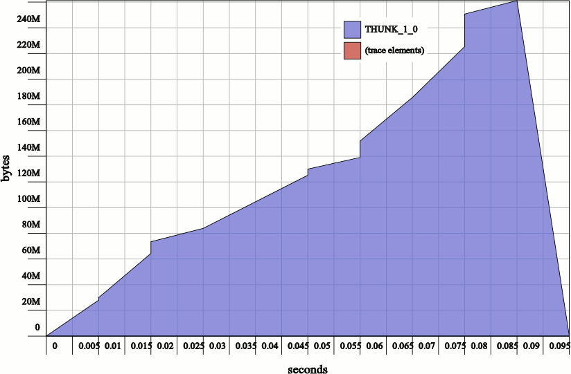

  This looks like a **thunk leak**.

# Heap Profiling *(cont.)*

- Let's try adding strictness to force evaluation:

  ```haskell
  count :: [Int] -> (Int,Int) -> (Int,Int)
  count []     !np    = np
  count (x:xs) !(n,p) = f xs (if x<0 then (n+1,p) else (n,p+1))
  ```

  ...but this doesn't seem to make any difference at all!
- That's because forcing `(⊥,⊥)` to WHNF is a no-op.

# Heap Profiling *(cont.)*

- Let's try *again* adding strictness to force evaluation:

  ```haskell
  count :: [Int] -> (Int,Int) -> (Int,Int)
  count []     np    = np
  count (x:xs) (!n,!p) = f xs (if x<0 then (n+1,p) else (n,p+1))
  ```

  Core `-O2`:

  ```haskell
  count_$s$wcount :: [Int] -> Int# -> Int# -> (# Int, Int #)
  count_$s$wcount = \ w n p ->
    case sc of _ {
      []     -> (# I# n, I# p #);
      : x xs -> case x of _ {
                  I# x1 -> case <# x1 0 of _ {
                    False -> count_$s$wcount xs n (+# p 1) ;
                    True  -> count_$s$wcount xs (+# n 1) p
                           }
                }
    }

  …
  ```

- Now, the curried `n` and `p` function arguments are unboxed `Int#`s.

# Heap Profiling *(cont.)*

- New statistics:

  ```
    987,695,672 bytes allocated in the heap
         84,648 bytes copied during GC
         36,080 bytes maximum residency (11 sample(s))
         21,264 bytes maximum slop
              1 MB total memory in use (0 MB lost due to fragmentation)
  …
  Productivity 100.0% of total user, 92.6% of total elapsed
  ```

- ..versus previous statistics:

  ```
  1,283,991,912 bytes allocated in the heap
  3,062,980,520 bytes copied during GC
    261,147,880 bytes maximum residency (26 sample(s))
      4,701,992 bytes maximum slop
            515 MB total memory in use (0 MB lost due to fragmentation)
  …
  Productivity   4.0% of total user, 3.8% of total elapsed
  ```

- From 4% to 100% productivity by adding just two `!` annotations!

# Heap Profiling *(cont.)*

- Optimized version's heap diagram:

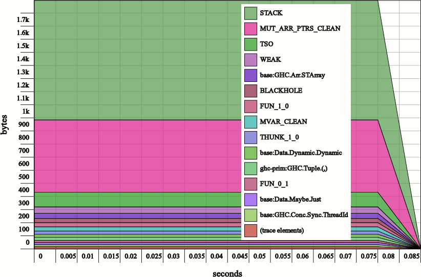

# Thunk leaks, Space Leaks, Stack Overflows...

- The first version of `sum` had only a **stack overflow** because it wasn't tail-recursive.
- The `count` example had a **thunk leak** (which often goes hand in hand with stack overflows), because thunks were accumulating on the heap.
- And then there's the (ordinary) **space leak**...

# Space Leaks

- Consider

  ```haskell
  let xs = [1..10000000::Int] -- that's 1e7 items
  in sum xs * product xs
  ```

  which results in

  ```
     800,041,392 bytes allocated in the heap
   2,777,788,352 bytes copied during GC
     399,735,000 bytes maximum residency (19 sample(s))
      68,504,360 bytes maximum slop
             908 MB total memory in use (0 MB lost due to fragmentation)
  …
  Productivity   4.1% of total user, 3.8% of total elapsed
  ```

- Remember that `[Int]` requires up to (3+2)*N* words.

# Space Leaks *(cont.)*

- And here's the resulting heap diagram:

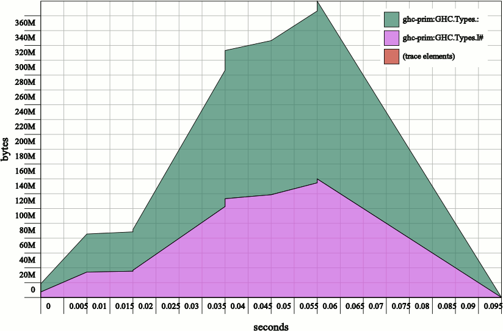

# Space Leaks *(cont.)*

- The reason can be explained by looking at the Core output for

  ```haskell
  let xs = [1..10000000::Int] -- that's 1e7 items
  in sum xs * product xs
  ```

  which is

  ```haskell
  result = case $wsum' xs 0 of ww {
             __DEFAULT -> case $wprod xs 1 of ww1 {
                             __DEFAULT -> I# (*# ww ww1)
                          }
           }

  xs = eftInt 1 10000000 -- [1..10000000]
  ```

  Here `xs` is allocated and kept alive until `$wprod` has been evaluated.
- CSE can be harmful: the code below has same Core output!

  ```haskell
  let x = product [1..10^7::Int]
      y = sum     [1..10^7::Int]
  in x*y
  ```

# Further reading

- [Profiling Memory Usage](http://www.haskell.org/ghc/docs/7.6.3/html/users_guide/prof-heap.html) chapter in *GHC User's Guide*
- [Profiling and Optimization](http://book.realworldhaskell.org/read/profiling-and-optimization.html) chapter in *Real World Haskell*
- E.Z.Yang's ["Space Leak" tagged blog posts](http://blog.ezyang.com/category/haskell/space-leak/)